# Assignment1

Daniel Yowell

2023-09-04

# Total questions completed: 15/15

# 1. Summarize how I will workout your final grade for the course. Give percentages etc. Give my grading scale also e.g. What percentage is an A etc

MATH 4753 Grade Visualization:

• 30% comes from the final.  
• 20% comes from midterms (2 worth 10% each).  
• 15% comes from a cumulative 4 assignments.  
• 10% comes from projects (a third of this grade comes from Project 1, the rest from Project 2).  
• 10% comes from labs.  
• 10% comes from in-class quizzes.  
• 5% comes from online Canvas quizzes on each chapter.

Some points may also be derived from minilab reports and additional class exercises.

Letter grades are assigned as:

• A: 90s  
• B: 80s  
• C: 60s-70s  
• D: 50s  
• F: < 50

There are no curves.

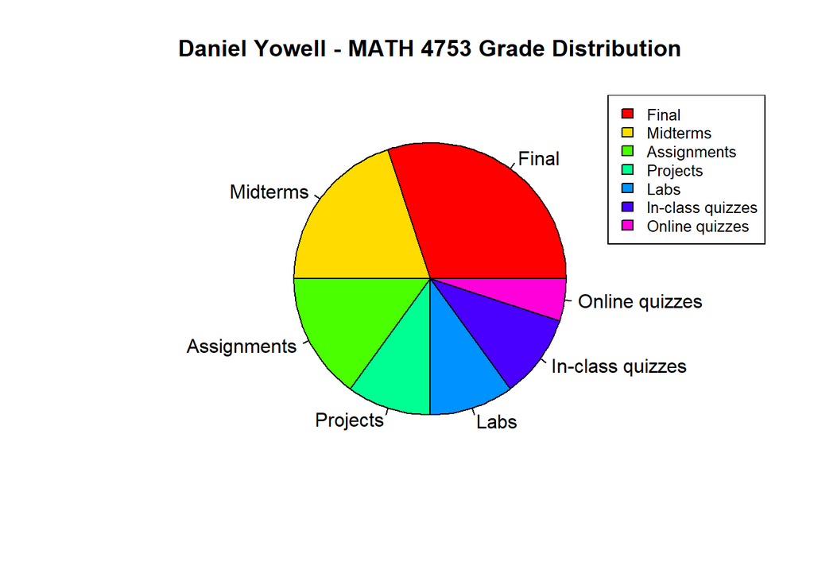

```r
grades <- c(
  "Final" = 30,
  "Midterms" = 20,
  "Assignments" = 15,
  "Projects" = 10,
  "Labs" = 10,
  "In-class quizzes" = 10,
  "Online quizzes" = 5
  )

# Customizing the pie chart
pie(grades, labels = names(grades), col = rainbow(length(grades)), main = "Daniel Yowell - MATH 4753 Grade Distribution")
legend("topright", cex=0.8, legend = names(grades), fill = rainbow(length(grades)))
```